# Introduction to the tidyverse

## Getting started

```r
if (!require("tidyverse")) install.packages(c("tidyverse")) # Only installs if missing
library(tidyverse)
```

A glimpse of the data

```r
head(diamonds) # diamonds is a built-in dataset in the tidyverse (ggplot2, actually)
```

| carat | cut | color | clarity | depth | table | price | x | y | z |
| --- | --- | --- | --- | --- | --- | --- | --- | --- | --- |
| 0.23 | Ideal | E | SI2 | 61.5 | 55 | 326 | 3.95 | 3.98 | 2.43 |
| 0.21 | Premium | E | SI1 | 59.8 | 61 | 326 | 3.89 | 3.84 | 2.31 |
| 0.23 | Good | E | VS1 | 56.9 | 65 | 327 | 4.05 | 4.07 | 2.31 |
| 0.29 | Premium | I | VS2 | 62.4 | 58 | 334 | 4.20 | 4.23 | 2.63 |
| 0.31 | Good | J | SI2 | 63.3 | 58 | 335 | 4.34 | 4.35 | 2.75 |
| 0.24 | Very Good | J | VVS2 | 62.8 | 57 | 336 | 3.94 | 3.96 | 2.48 |

```r
# Below the name of the variable, you will find the variable type:
# dbl  = double = real number,
# int  = integer = integer number,
# ord  = ordered factor,
# fact = unordered factor,
# char = character.
tail(diamonds)
```

| carat | cut | color | clarity | depth | table | price | x | y | z |
| --- | --- | --- | --- | --- | --- | --- | --- | --- | --- |
| 0.72 | Premium | D | SI1 | 62.7 | 59 | 2757 | 5.69 | 5.73 | 3.58 |
| 0.72 | Ideal | D | SI1 | 60.8 | 57 | 2757 | 5.75 | 5.76 | 3.50 |
| 0.72 | Good | D | SI1 | 63.1 | 55 | 2757 | 5.69 | 5.75 | 3.61 |
| 0.70 | Very Good | D | SI1 | 62.8 | 60 | 2757 | 5.66 | 5.68 | 3.56 |
| 0.86 | Premium | H | SI2 | 61.0 | 58 | 2757 | 6.15 | 6.12 | 3.74 |
| 0.75 | Ideal | D | SI2 | 62.2 | 55 | 2757 | 5.83 | 5.87 | 3.64 |

## First plots

A first example:

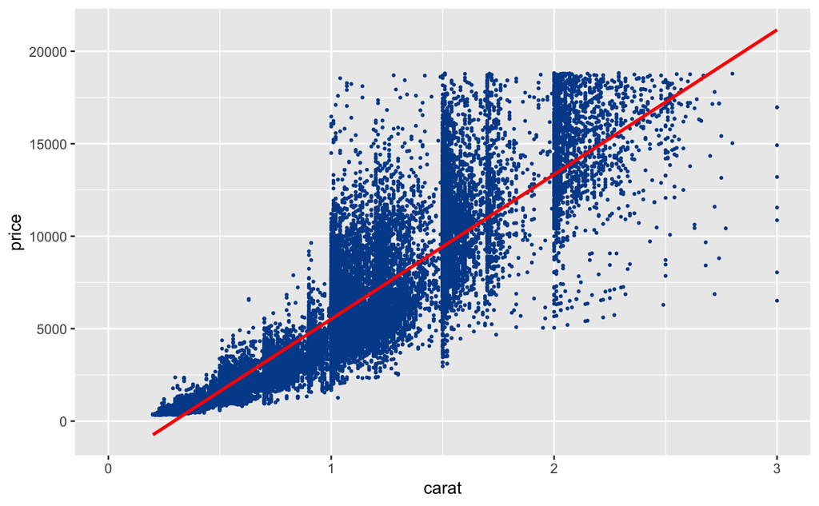

```r
ggplot(diamonds) + geom_point(aes(x = carat, y = price), size = 0.5, color = "#004C99") + xlim(0,3) +
    stat_smooth(aes(x =carat, y = price), method = "lm", color = "red")
```

We can add features.

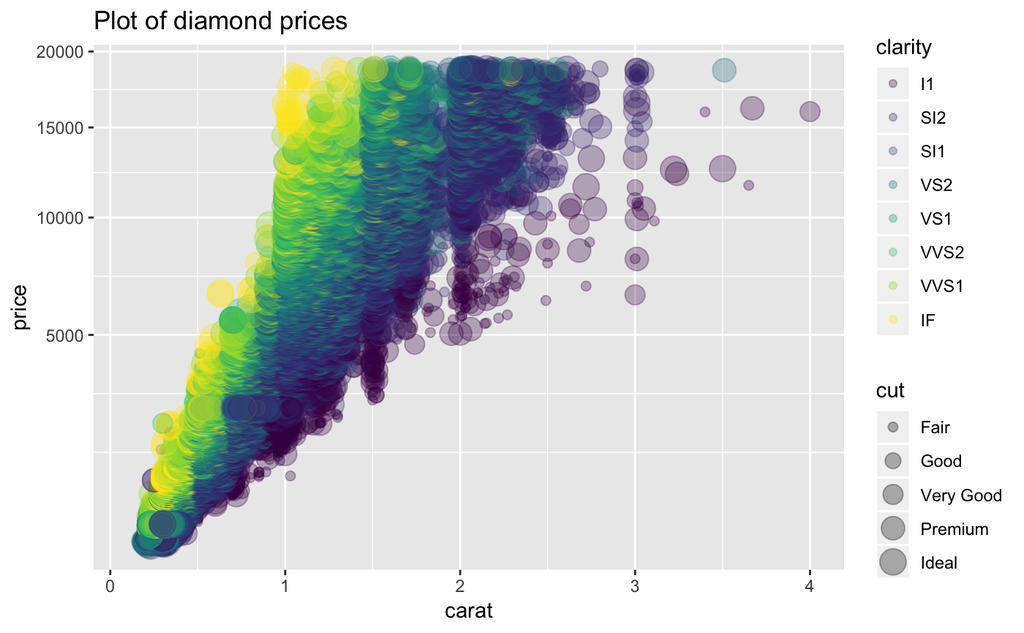

```r
ggplot(diamonds) + geom_point(aes(x = carat, y = price, color = clarity, size = cut), alpha = 3/10) +
  scale_y_sqrt() + ggtitle("Plot of diamond prices") + xlim(0.1,4)
```

Another popular graph type is the bar plot.

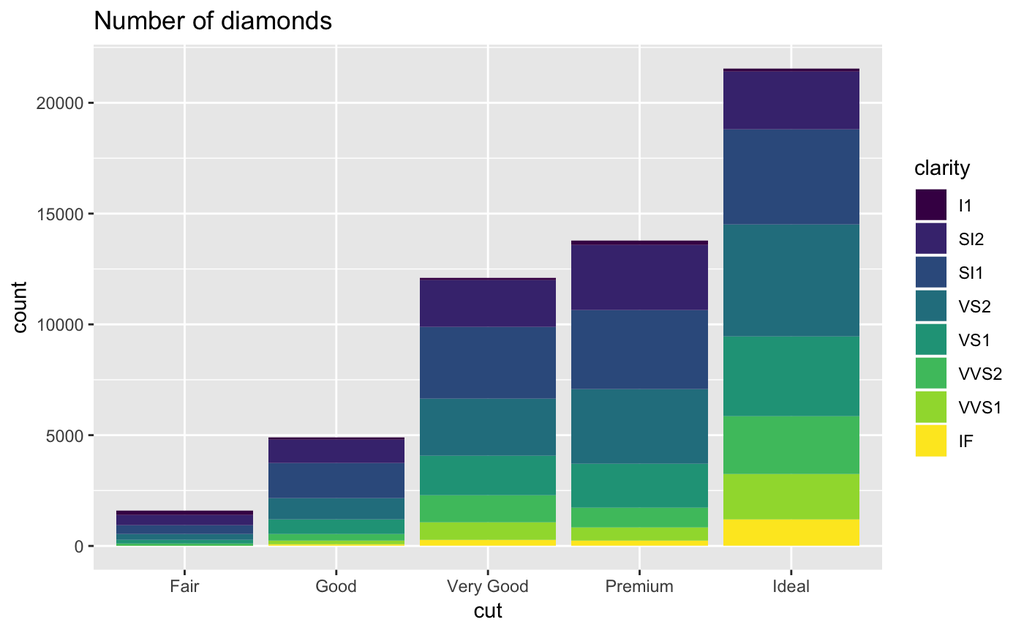

```r
ggplot(diamonds) + geom_bar(aes(x = cut, fill = clarity)) + ggtitle("Number of diamonds")
```

Plotting is closely related to layers (like in Photoshop). Several layers can be superposed. Alternative colour palettes can be used.

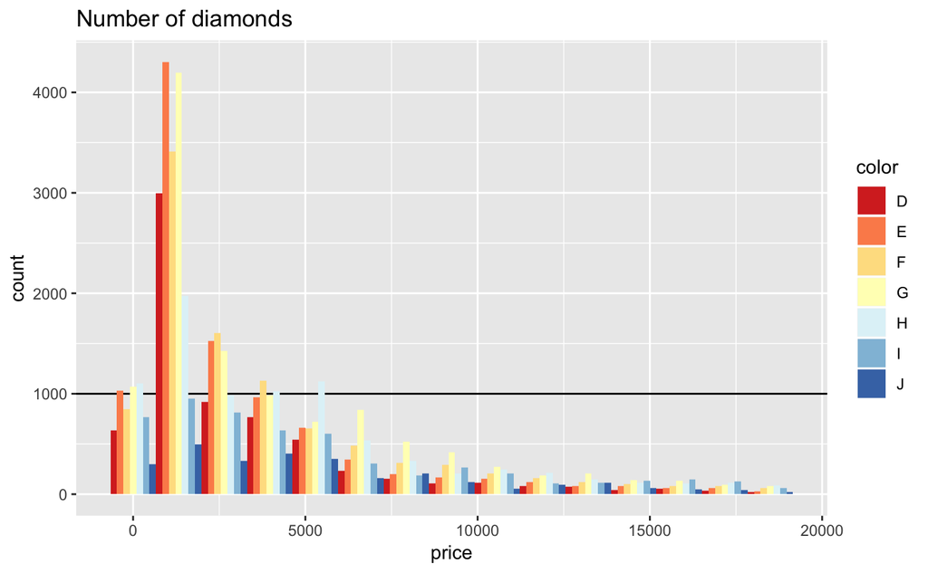

```r
ggplot(diamonds,aes(x = price, fill = color)) + geom_hline(yintercept = 1000) +
  geom_histogram(bins = 15, position= "dodge") + ggtitle("Number of diamonds") +
    scale_fill_brewer(palette = "RdYlBu")
```

Further references for graph types:  
https://developers.google.com/chart/interactive/docs/gallery  
https://plot.ly/r/  
https://www.r-graph-gallery.com/all-graphs/  
https://plot.ly/r/shiny-gallery/ (dynamic & interactive)

## Data manipulation

First, it is imperative to get to know the data.

```r
summary(diamonds)
```

```
     carat               cut        color        clarity          depth           table           price             x
 Min.   :0.2000   Fair     : 1610   D: 6775   SI1    :13065   Min.   :43.00   Min.   :43.00   Min.   :  326   Min.   : 0.000
 1st Qu.:0.4000   Good     : 4906   E: 9797   VS2    :12258   1st Qu.:61.00   1st Qu.:56.00   1st Qu.:  950   1st Qu.: 4.710
 Median :0.7000   Very Good:12082   F: 9542   SI2    : 9194   Median :61.80   Median :57.00   Median : 2401   Median : 5.700
 Mean   :0.7979   Premium  :13791   G:11292   VS1    : 8171   Mean   :61.75   Mean   :57.46   Mean   : 3933   Mean   : 5.731
 3rd Qu.:1.0400   Ideal    :21551   H: 8304   VVS2   : 5066   3rd Qu.:62.50   3rd Qu.:59.00   3rd Qu.: 5324   3rd Qu.: 6.540
 Max.   :5.0100                     I: 5422   VVS1   : 3655   Max.   :79.00   Max.   :95.00   Max.   :18823   Max.   :10.740
                                    J: 2808   (Other): 2531
       y                z
 Min.   : 0.000   Min.   : 0.000
 1st Qu.: 4.720   1st Qu.: 2.910
 Median : 5.710   Median : 3.530
 Mean   : 5.735   Mean   : 3.539
 3rd Qu.: 6.540   3rd Qu.: 4.040
 Max.   :58.900   Max.   :31.800
```

Often, people are interested by subsets of databases.

```r
filter(diamonds, carat > 4)
```

| carat | cut | color | clarity | depth | table | price | x | y | z |
| --- | --- | --- | --- | --- | --- | --- | --- | --- | --- |
| 4.01 | Premium | I | I1 | 61.0 | 61 | 15223 | 10.14 | 10.10 | 6.17 |
| 4.01 | Premium | J | I1 | 62.5 | 62 | 15223 | 10.02 | 9.94 | 6.24 |
| 4.13 | Fair | H | I1 | 64.8 | 61 | 17329 | 10.00 | 9.85 | 6.43 |
| 5.01 | Fair | J | I1 | 65.5 | 59 | 18018 | 10.74 | 10.54 | 6.98 |
| 4.50 | Fair | J | I1 | 65.8 | 58 | 18531 | 10.23 | 10.16 | 6.72 |

```r
filter(diamonds, carat > 3 & cut == "Ideal")
```

| carat | cut | color | clarity | depth | table | price | x | y | z |
| --- | --- | --- | --- | --- | --- | --- | --- | --- | --- |
| 3.22 | Ideal | I | I1 | 62.6 | 55 | 12545 | 9.49 | 9.42 | 5.92 |
| 3.50 | Ideal | H | I1 | 62.8 | 57 | 12587 | 9.65 | 9.59 | 6.03 |
| 3.01 | Ideal | J | SI2 | 61.7 | 58 | 16037 | 9.25 | 9.20 | 5.69 |
| 3.01 | Ideal | J | I1 | 65.4 | 60 | 16538 | 8.99 | 8.93 | 5.86 |

Sometimes, only a few columns matter and it can be useful to only keep those (possibly in a separate variable).

```r
select(diamonds, carat, cut, color, price)
```

| carat | cut | color | price |
| --- | --- | --- | --- |
| 0.23 | Ideal | E | 326 |
| 0.21 | Premium | E | 326 |
| 0.23 | Good | E | 327 |
| 0.29 | Premium | I | 334 |
| 0.31 | Good | J | 335 |
| 0.24 | Very Good | J | 336 |
| 0.24 | Very Good | I | 336 |
| 0.26 | Very Good | H | 337 |
| 0.22 | Fair | E | 337 |
| 0.23 | Very Good | H | 338 |

[output cut: 990 more lines]

```r
select(diamonds, - clarity, - x, - y, - z) # Using the minus sign performs the opposite manipulation and removes the corresponding variable
```

| carat | cut | color | depth | table | price |
| --- | --- | --- | --- | --- | --- |
| 0.23 | Ideal | E | 61.5 | 55.0 | 326 |
| 0.21 | Premium | E | 59.8 | 61.0 | 326 |
| 0.23 | Good | E | 56.9 | 65.0 | 327 |
| 0.29 | Premium | I | 62.4 | 58.0 | 334 |
| 0.31 | Good | J | 63.3 | 58.0 | 335 |
| 0.24 | Very Good | J | 62.8 | 57.0 | 336 |
| 0.24 | Very Good | I | 62.3 | 57.0 | 336 |
| 0.26 | Very Good | H | 61.9 | 55.0 | 337 |
| 0.22 | Fair | E | 65.1 | 61.0 | 337 |
| 0.23 | Very Good | H | 59.4 | 61.0 | 338 |

[output cut: 990 more lines]

Data manipulation is all about sequences of tasks: filtering rows, selecting columns, re-arranging, plotting, etc. A very convenient way to write these sequences is to resort to the **PIPE** operator **%>%**. It works like this:  
Data variable %>% Instruction 1 %>% Instruction 2 %>% Instruction 3 %>% …  
Below, we apply successively a filter and a selection. On top of that, you can add a plot.

```r
filter(diamonds, carat > 4) %>% select(carat, cut, color, price) # Or, equivalently,
```

| carat | cut | color | price |
| --- | --- | --- | --- |
| 4.01 | Premium | I | 15223 |
| 4.01 | Premium | J | 15223 |
| 4.13 | Fair | H | 17329 |
| 5.01 | Fair | J | 18018 |
| 4.50 | Fair | J | 18531 |

```r
diamonds %>%
    filter(carat > 4) %>%
    select(carat, cut, color, price)
```

| carat | cut | color | price |
| --- | --- | --- | --- |
| 4.01 | Premium | I | 15223 |
| 4.01 | Premium | J | 15223 |
| 4.13 | Fair | H | 17329 |
| 5.01 | Fair | J | 18018 |
| 4.50 | Fair | J | 18531 |

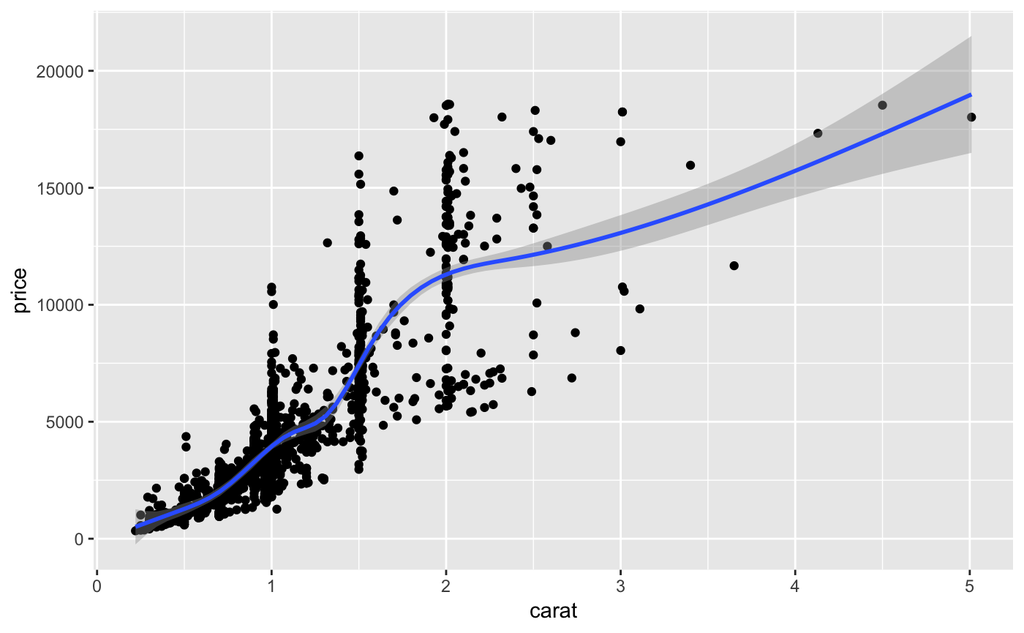

```r
diamonds %>%
    filter(cut == "Fair") %>%
    ggplot(aes(x = carat, y = price)) + geom_point() + geom_smooth()
```

```r
# The last part aims to ease visual pattern detection
```

The tidyverse is very efficient at building pivot tables. Effortlessly (almost), they can then be plotted.

```r
diamonds %>%
    group_by(cut) %>%
    summarize(number = n(), avg_price = mean(price)) # n() simply counts the number of occurrences
```

| cut | number | avg_price |
| --- | --- | --- |
| Fair | 1610 | 4358.758 |
| Good | 4906 | 3928.864 |
| Very Good | 12082 | 3981.760 |
| Premium | 13791 | 4584.258 |
| Ideal | 21551 | 3457.542 |

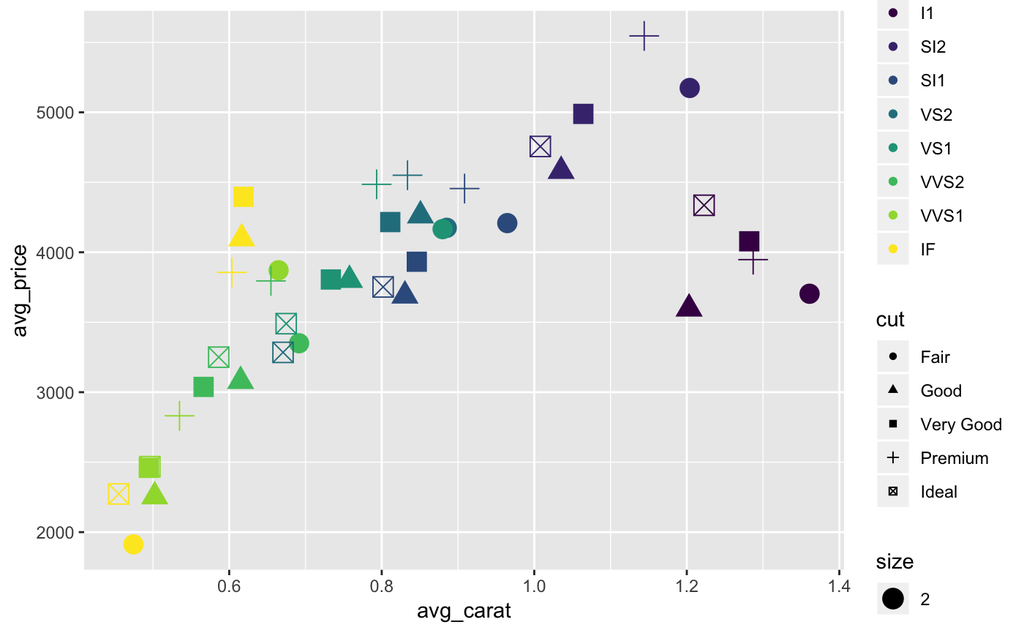

```r
diamonds %>%
    group_by(cut, clarity) %>%
    summarize(avg_carat = mean(carat), avg_price = mean(price)) %>%
    #arrange(avg_price)
    ggplot() + geom_point(aes(x = avg_carat, y = avg_price, color = clarity, shape = cut, size = 2)) # Yes, you can control the point size!
```

Rectangular data can be organized is several ways.

```r
diamonds %>% group_by(cut, color) %>% summarize(avg_price = mean(price)) # one way to see things.. how do I get a matrix out of this? => spread()!
diamonds %>% group_by(cut, color) %>% summarize(avg_price = mean(price)) %>% spread(key = cut, value = avg_price)
```

[output not shown]